# GetSmartLook analýza

Tento dokument ukazuje analýzu dát od GetSmartLook.

## Zdroj a rozsah dát

Tieto dáta sú z obdobia medzi 6. a 12. májom 2016 a pochádzajú predovšetkým zo stránok GetSmartLook.

## Spracované, agregované dáta

Surové `JSON` dáta sme spracovali parserom, ktorý sme napísali na základe ukážkového `JSON` súboru, ktorý sme dostali vopred. Z tohto parseru sme dostali `csv` súbory, v ktorom sú uložené všetky "udalosti" ako kliky, pohyby, scrolls.

Následne sme tieto dáta spracovali do agregovaných štatistík na úrovni jednotlivých sessions. To znamená, že na základe udalostí z vyparsovaných `csv` súborov sme pre každú session vypočítali premenné ako "vzdialenosť", "frekvencia klikov", atď.

Tento dokument ukáže, čo sa momentálne s dátami dá robiť, ako sme ich spracovali a aké prvé analýzy a poznatky z nich vieme zohnať. Zatiaľ na menšej vzorke.

```python
import os
# agregovane data
agg_data_folder = '../data/agg_final/'
print('Pocet agregovanych csv suborov:')
print(len(os.listdir(agg_data_folder)))
```

```
Pocet agregovanych csv suborov:
436
```

```python
import pandas as pd
# nacitat csv do pandas dataframes
agg_frames = {}
agg_sess = {}
for csv in os.listdir(agg_data_folder):
    f, ext = os.path.splitext(csv)
    if ext != '.csv':
        continue
    agg_frames[f] = pd.read_csv(os.path.join(agg_data_folder, csv), index_col=0)
    agg_sess[f] = len(agg_frames[f].values)
    #print('V subore %s sa nachadza takyto pocet sessions: %d' % (csv, agg_sess[f]))
```

```python
def sum_dict(d):
    s = 0
    for entry in d.iteritems():
        if type(entry[1]) not in [int, float, bool]:
            continue
        s += entry[1]
    return s
# spocitaj pocet sessions
total_session_count = sum_dict(agg_sess)
print('Celkovy pocet sessions je %d' % total_session_count)
```

```
Celkovy pocet sessions je 88615
```

```python
def merge_dict_frames(d):
    keys = d.keys()
    final_frame = d[keys[0]]
    for key in keys[1:]:
        final_frame = final_frame.append(d[key], ignore_index=True)
    return final_frame

# skombinuj dataframes do jedneho
aggregated = merge_dict_frames(agg_frames)
print('Skombinovany dataset ma takyto tvar:')
aggregated = aggregated.drop_duplicates()
aggregated.shape
```

```
Skombinovany dataset ma takyto tvar:
```

```
(87745, 28)
```

```python
# odstran nulove sessions
aggregated = aggregated.loc[aggregated.session_uid != '0', :]
print('Po odstraneni prazdnych riadkov mame takyto tvar:')
print(aggregated.shape)
```

```
Po odstraneni prazdnych riadkov mame takyto tvar:
(87743, 28)
```

```python
# vytvor mapu serverov a cisiel od 0 do 1 pre farby
n_servers = len(aggregated.server.unique())
step = 1. / n_servers
server_map = {}
for i,s in enumerate(aggregated.server.unique()):
    server_map[s] = i*step
```

## Vizualizácie

Tu si ukážeme prvé grafy a vizualizácie vzťahov, ktoré môžeme v dátach vidieť.

Taktiež sa pozeráme na nejaké prvé vzťahy:

```python
import matplotlib
import matplotlib.pyplot as plt
%matplotlib notebook
from matplotlib import colors
matplotlib.style.use('ggplot')
c = 1 - aggregated.server.map(server_map).values
cmap = plt.get_cmap('gist_rainbow')


def my_scatter(ix, x, y, s, title, xlab, ylab, c=c):
    plt.figure(ix)
    plt.scatter(x, y, s=s, c=c, cmap=cmap)
    plt.title(title)
    plt.xlabel(xlab)
    plt.ylabel(ylab)
    plt.show()
```

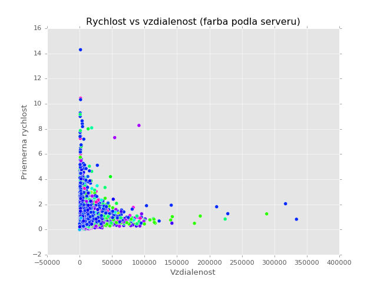

```python
# zafarbene podla serveru
x = aggregated.distance.values
y = aggregated.mean_velocity.values
title = 'Rychlost vs vzdialenost (farba podla serveru)'
ylabel = 'Priemerna rychlost'
xlabel = 'Vzdialenost'
my_scatter(0, x, y, 30, title, xlabel, ylabel)
```

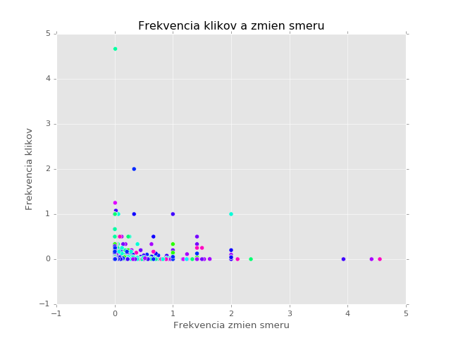

```python
x = aggregated.freq_change.values
y = aggregated.click_freq.values
title = 'Frekvencia klikov a zmien smeru'
xlabel='Frekvencia zmien smeru'
ylabel='Frekvencia klikov'
my_scatter(1, x, y, 30, title, xlabel, ylabel)
```

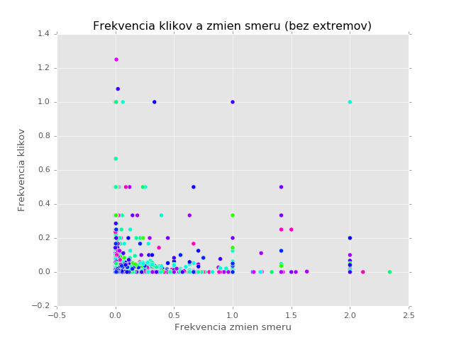

```python
# prec outliers
a2 = aggregated.loc[aggregated.freq_change < 3, :]
a2 = a2.loc[aggregated.click_freq < 1.5, :]
x2 = a2.freq_change.values
y2 = a2.click_freq.values
c2 = 1-a2.server.map(server_map).values
t2 = 'Frekvencia klikov a zmien smeru (bez extremov)'
my_scatter(2, x2, y2, 30, t2, xlabel, ylabel, c=c2)
```

```python
pd.set_option('precision', 3)
```

## Korelácie premenných

```python
# cisty dataframe bez metadat
variables_only = aggregated.drop(['server', 'session_uid', 'empty_click_freq', 'mean_miss', 'log_count'], axis=1)
variables_only.corr()
```

|  | click_freq | distance | double_click_freq | freq_change | latency | mean_acc | mean_deac | mean_velocity | peak_acc | peak_deac | ... | scroll_mean_acc_down | scroll_mean_acc_up | scroll_mean_vel_down | scroll_mean_vel_up | scroll_mean_velocity | scroll_peak_acc_down | scroll_peak_acc_up | scroll_peak_vel_down | scroll_peak_vel_up | scroll_peak_velocity |
| --- | --- | --- | --- | --- | --- | --- | --- | --- | --- | --- | --- | --- | --- | --- | --- | --- | --- | --- | --- | --- | --- |
| click_freq | 1.000e+00 | -1.939e-02 | 3.655e-01 | 0.067 | -1.220e-03 | 0.063 | -4.708e-02 | 0.008 | 2.488e-03 | 0.006 | ... | -0.020 | -0.015 | -0.015 | -0.020 | -1.731e-02 | -0.023 | -0.021 | -0.022 | -0.023 | -0.023 |
| distance | -1.939e-02 | 1.000e+00 | -1.790e-05 | -0.030 | 9.849e-04 | -0.011 | 6.178e-04 | 0.297 | 3.783e-01 | -0.377 | ... | 0.182 | 0.200 | 0.192 | 0.138 | 9.462e-02 | 0.195 | 0.221 | 0.207 | 0.188 | 0.187 |
| double_click_freq | 3.655e-01 | -1.790e-05 | 1.000e+00 | 0.013 | -2.416e-04 | 0.004 | -1.085e-03 | 0.004 | 2.440e-04 | 0.001 | ... | -0.004 | -0.004 | -0.004 | -0.004 | -4.274e-03 | -0.004 | -0.004 | -0.004 | -0.004 | -0.004 |
| freq_change | 6.693e-02 | -3.004e-02 | 1.349e-02 | 1.000 | -1.582e-03 | -0.073 | 6.554e-02 | -0.074 | -8.260e-02 | 0.076 | ... | 0.038 | 0.044 | 0.041 | 0.031 | 4.131e-02 | 0.020 | 0.023 | 0.020 | 0.017 | 0.018 |
| latency | -1.220e-03 | 9.849e-04 | -2.416e-04 | -0.002 | 1.000e+00 | 0.015 | -1.344e-02 | 0.008 | 1.242e-02 | -0.013 | ... | -0.002 | -0.003 | -0.003 | 0.002 | -8.805e-04 | 0.002 | 0.002 | 0.002 | 0.004 | 0.004 |
| mean_acc | 6.338e-02 | -1.074e-02 | 4.237e-03 | -0.073 | 1.468e-02 | 1.000 | -8.851e-01 | 0.260 | 5.466e-01 | -0.490 | ... | -0.040 | -0.048 | -0.030 | 0.021 | -2.234e-02 | 0.038 | 0.025 | 0.035 | 0.062 | 0.067 |
| mean_deac | -4.708e-02 | 6.178e-04 | -1.085e-03 | 0.066 | -1.344e-02 | -0.885 | 1.000e+00 | -0.207 | -5.121e-01 | 0.542 | ... | 0.024 | 0.033 | 0.015 | -0.023 | 1.129e-02 | -0.056 | -0.039 | -0.051 | -0.073 | -0.077 |
| mean_velocity | 8.388e-03 | 2.965e-01 | 3.646e-03 | -0.074 | 7.893e-03 | 0.260 | -2.067e-01 | 1.000 | 5.179e-01 | -0.478 | ... | -0.002 | 0.024 | 0.027 | -0.017 | -8.803e-03 | -0.034 | -0.020 | -0.025 | -0.035 | -0.035 |
| peak_acc | 2.488e-03 | 3.783e-01 | 2.440e-04 | -0.083 | 1.242e-02 | 0.547 | -5.121e-01 | 0.518 | 1.000e+00 | -0.958 | ... | 0.136 | 0.145 | 0.147 | 0.146 | 1.022e-01 | 0.167 | 0.176 | 0.178 | 0.183 | 0.185 |
| peak_deac | 6.114e-03 | -3.771e-01 | 1.376e-03 | 0.076 | -1.307e-02 | -0.490 | 5.417e-01 | -0.478 | -9.580e-01 | 1.000 | ... | -0.145 | -0.153 | -0.154 | -0.147 | -1.075e-01 | -0.175 | -0.182 | -0.185 | -0.188 | -0.189 |
| peak_velocity | -2.227e-04 | 3.949e-01 | -1.119e-04 | -0.085 | 1.251e-02 | 0.530 | -4.998e-01 | 0.541 | 9.904e-01 | -0.962 | ... | 0.149 | 0.160 | 0.161 | 0.156 | 1.081e-01 | 0.175 | 0.185 | 0.187 | 0.191 | 0.193 |
| scroll_distance | -7.750e-03 | 2.038e-01 | -1.113e-03 | 0.012 | -1.561e-04 | -0.022 | 1.626e-02 | -0.013 | 6.752e-02 | -0.071 | ... | 0.630 | 0.593 | 0.528 | 0.523 | 6.692e-01 | 0.649 | 0.688 | 0.631 | 0.592 | 0.591 |
| scroll_mean_acc_down | -1.981e-02 | 1.816e-01 | -3.607e-03 | 0.038 | -1.753e-03 | -0.040 | 2.361e-02 | -0.002 | 1.363e-01 | -0.145 | ... | 1.000 | 0.936 | 0.888 | 0.820 | 8.907e-01 | 0.789 | 0.817 | 0.787 | 0.743 | 0.744 |
| scroll_mean_acc_up | -1.458e-02 | 2.000e-01 | -3.966e-03 | 0.044 | -2.565e-03 | -0.048 | 3.297e-02 | 0.024 | 1.449e-01 | -0.153 | ... | 0.936 | 1.000 | 0.948 | 0.779 | 8.262e-01 | 0.724 | 0.788 | 0.733 | 0.689 | 0.689 |
| scroll_mean_vel_down | -1.530e-02 | 1.920e-01 | -3.572e-03 | 0.041 | -2.504e-03 | -0.030 | 1.527e-02 | 0.027 | 1.470e-01 | -0.154 | ... | 0.888 | 0.948 | 1.000 | 0.685 | 7.740e-01 | 0.667 | 0.727 | 0.684 | 0.629 | 0.637 |
| scroll_mean_vel_up | -1.956e-02 | 1.378e-01 | -4.489e-03 | 0.031 | 1.691e-03 | 0.021 | -2.343e-02 | -0.017 | 1.456e-01 | -0.147 | ... | 0.820 | 0.779 | 0.685 | 1.000 | 7.329e-01 | 0.757 | 0.800 | 0.743 | 0.794 | 0.792 |
| scroll_mean_velocity | -1.731e-02 | 9.462e-02 | -4.274e-03 | 0.041 | -8.805e-04 | -0.022 | 1.129e-02 | -0.009 | 1.022e-01 | -0.107 | ... | 0.891 | 0.826 | 0.774 | 0.733 | 1.000e+00 | 0.759 | 0.781 | 0.748 | 0.712 | 0.711 |
| scroll_peak_acc_down | -2.291e-02 | 1.952e-01 | -3.700e-03 | 0.020 | 2.375e-03 | 0.038 | -5.598e-02 | -0.034 | 1.667e-01 | -0.175 | ... | 0.789 | 0.724 | 0.667 | 0.757 | 7.587e-01 | 1.000 | 0.955 | 0.978 | 0.966 | 0.966 |
| scroll_peak_acc_up | -2.150e-02 | 2.206e-01 | -3.852e-03 | 0.023 | 1.813e-03 | 0.025 | -3.853e-02 | -0.020 | 1.761e-01 | -0.182 | ... | 0.817 | 0.788 | 0.727 | 0.800 | 7.805e-01 | 0.955 | 1.000 | 0.951 | 0.951 | 0.951 |
| scroll_peak_vel_down | -2.247e-02 | 2.068e-01 | -3.680e-03 | 0.020 | 1.996e-03 | 0.035 | -5.108e-02 | -0.025 | 1.775e-01 | -0.185 | ... | 0.787 | 0.733 | 0.684 | 0.743 | 7.478e-01 | 0.978 | 0.951 | 1.000 | 0.957 | 0.960 |
| scroll_peak_vel_up | -2.340e-02 | 1.882e-01 | -4.232e-03 | 0.017 | 3.865e-03 | 0.062 | -7.281e-02 | -0.035 | 1.835e-01 | -0.188 | ... | 0.743 | 0.689 | 0.629 | 0.794 | 7.120e-01 | 0.966 | 0.951 | 0.957 | 1.000 | 0.999 |
| scroll_peak_velocity | -2.317e-02 | 1.873e-01 | -4.068e-03 | 0.018 | 3.912e-03 | 0.067 | -7.745e-02 | -0.035 | 1.852e-01 | -0.189 | ... | 0.744 | 0.689 | 0.637 | 0.792 | 7.114e-01 | 0.966 | 0.951 | 0.960 | 0.999 | 1.000 |

22 rows × 22 columns

## Výpočet štandardov (baselines)

Keď sme načítali a pospájali agregované dáta, môžeme na základe týchto sessions vypočítať štandardy správania. Spravíme tak globálne, ako aj zvlášť pre každý server, ktorý v dátach máme.

Štandardy (baselines) slúžia na identifikáciu "najzvláštnejších" (a teda najzaujímavejších) sessions.

Keďže pre každú premennú vypočítame priemer aj štandardnú odchýlku, dokážeme pre každú session vypočítať, ako ďaleko sú od priemeru (koľko štandardných odchýliek). Ak bude táto hodnota pre akúkoľvek premennú výrazne odlišná (`sigma` aspoň 4, teda 4 štandardné odchýlku), označíme si ich. Tak dokážeme identifikovať sessions, ktoré majú pri najväčšom počte premenných výrazné odchýlky.

Takýto postup vieme aplikovať aj na úrovni serveru - pre každý server vieme vypočítať odlišné štandardy a porovnávať tak sessions podľa vhodných štandardov.

### Štandardy pre celý dataset (globálne baselines)

```python
from baselines import compute_baselines

# zachytime problematicke, chybne hodnoty ako '[0.0]'
for key in aggregated:
    aggregated.loc[:,key] = aggregated[key].apply(lambda x: 0.0 if x == '[0.0]' else x)

# odstranime premenne, z ktorych nechceme baselines pocitat
clean_agg = aggregated.drop(['session_uid', 'server'], axis=1)
# zmenime vsetko na float
clean_agg = clean_agg.astype(float)
# vypocitame baselines
means, variances, covariance, count = compute_baselines(clean_agg)
```

```python
import numpy as np

# z baselines si vytvorime dataframe
var_names = clean_agg.keys()
# standardna odchylka
std_dev = np.sqrt(variances)
# spoj do velkeho pola
baselines = np.array([means, variances, std_dev])
# sprav dataframe
baseline_df = pd.DataFrame(baselines, columns=var_names, index=['mean', 'variance', 'std_dev'])
baseline_df
```

|  | click_freq | distance | double_click_freq | empty_click_freq | freq_change | latency | log_count | mean_acc | mean_deac | mean_miss | ... | scroll_mean_acc_down | scroll_mean_acc_up | scroll_mean_vel_down | scroll_mean_vel_up | scroll_mean_velocity | scroll_peak_acc_down | scroll_peak_acc_up | scroll_peak_vel_down | scroll_peak_vel_up | scroll_peak_velocity |
| --- | --- | --- | --- | --- | --- | --- | --- | --- | --- | --- | --- | --- | --- | --- | --- | --- | --- | --- | --- | --- | --- |
| mean | 9.278e-04 | 1.442e+04 | 6.659e-05 | 0.0 | 1.306e-02 | 2.880e+02 | 317.062 | 2.561e-02 | -2.204e-02 | 0.0 | ... | 0.353 | 0.347 | 9.129 | 14.043 | 2.761 | 1.258 | 1.212 | 34.583 | 36.127 | 36.263 |
| variance | 1.897e-04 | 7.436e+08 | 2.674e-06 | 0.0 | 3.562e-04 | 1.643e+08 | 314423.655 | 7.390e-04 | 5.799e-04 | 0.0 | ... | 0.364 | 0.323 | 195.104 | 583.451 | 50.698 | 6.147 | 5.872 | 4142.713 | 4212.569 | 4213.521 |
| std_dev | 1.377e-02 | 2.727e+04 | 1.635e-03 | 0.0 | 1.887e-02 | 1.282e+04 | 560.735 | 2.719e-02 | 2.408e-02 | 0.0 | ... | 0.604 | 0.568 | 13.968 | 24.155 | 7.120 | 2.479 | 2.423 | 64.364 | 64.904 | 64.912 |

3 rows × 26 columns

```python
# teraz vypocitajme standardizovane odchylky od baseline
deviations = clean_agg - means
standardized = deviations / std_dev
```

```python
# oznacme si odchylky, ktore su vacsie ako +/-4 (naozaj vyrazna odchylka)

# absolutne hodnoty
absolute = standardized.abs()
# vacsie ako 4
critical = absolute.values > 4
# sessions s najvacsim poctom odchyliek
by_session = critical.sum(axis=1)
absolute['dev_count'] = by_session
sorted_devs = absolute.sort_values('dev_count', ascending=False)
print('Top 10 najodchylenejsich sessions:')
aggregated['dev_count'] = absolute['dev_count']
aggregated.ix[sorted_devs.index, ['session_uid', 'dev_count', 'server']].head(10)
```

```
Top 10 najodchylenejsich sessions:
```

|  | session_uid | dev_count | server |
| --- | --- | --- | --- |
| 79182 | 572f88892544f7aa1da88524 | 13 | www.bandivamos.cz |
| 27918 | 5730f91ee435a215024718e3 | 12 | www.bandivamos.cz |
| 78343 | 572d8fa72edb8baa35fe223f | 11 | www.svetkrmiv.cz |
| 78606 | 5730f50e9c0f7a01028cc462 | 11 | extrashosteleria.com |
| 9831 | 572f182f2544f7aa1da86b73 | 11 | www.bandivamos.cz |
| 68392 | 572d1b1e8ee1cf001e3d1813 | 11 | www.bandivamos.cz |
| 72003 | 572c2e47c330a0b8540e248a | 11 | www.bandivamos.cz |
| 49889 | 572d9a453524cbbb350359dd | 11 | www.bandivamos.cz |
| 50448 | 572c413bc330a0b8540e28aa | 11 | www.bandivamos.cz |
| 64506 | 572e57242edb8baa35fe44ea | 11 | www.bandivamos.cz |

### Tri najodchýlenejšie sessions

```python
# pozrime sa teraz na niektore tieto sessions, napr. na prve tri
top3 = aggregated.ix[sorted_devs.index, :].head(3)
top3_dev = absolute.ix[sorted_devs.index, :].head(3)
top3_dev
```

|  | click_freq | distance | double_click_freq | empty_click_freq | freq_change | latency | log_count | mean_acc | mean_deac | mean_miss | ... | scroll_mean_acc_up | scroll_mean_vel_down | scroll_mean_vel_up | scroll_mean_velocity | scroll_peak_acc_down | scroll_peak_acc_up | scroll_peak_vel_down | scroll_peak_vel_up | scroll_peak_velocity | dev_count |
| --- | --- | --- | --- | --- | --- | --- | --- | --- | --- | --- | --- | --- | --- | --- | --- | --- | --- | --- | --- | --- | --- |
| 79182 | 0.024 | 0.584 | 0.041 | NaN | 0.661 | 0.022 | 0.546 | 43.720 | 49.506 | NaN | ... | 5.547 | 3.711 | 16.076 | 2.629 | 17.102 | 17.846 | 17.347 | 18.321 | 18.317 | 13 |
| 27918 | 0.057 | 0.391 | 0.041 | NaN | 4.268 | 0.022 | 0.105 | 0.743 | 0.704 | NaN | ... | 19.886 | 20.245 | 13.879 | 22.673 | 17.874 | 18.749 | 17.581 | 17.410 | 17.406 | 12 |
| 78343 | 0.016 | 0.468 | 0.041 | NaN | 0.053 | 0.022 | 0.430 | 0.136 | 0.101 | NaN | ... | 6.930 | 5.236 | 9.820 | 7.485 | 9.546 | 9.793 | 9.151 | 9.051 | 9.048 | 11 |

3 rows × 27 columns

Vidíme, že tieto sessions majú najväčšie odchýlky práve v scrollovaní. To znamená, že v týchto sessions sa scrollovalo výrazne rýchlejšie a viac ako zvyčajne.

V prvej session (`572f88892544f7aa1da88524`) je výrazná odchýlka aj zrýchlení a v spomalení (`mean_acc` a `mean_deac`). To znamená, že okrem rýchleho/dynamického scrollovania sa veľmi prudko menila aj rýchlosť pohybu myši.

V druhej session (`5730f91ee435a215024718e3`) je zas výrazný odchýlka pri frekvencii zmeny smeru (`freq_change`).

Pre podrobnosti by sme si museli pozrieť záznam daných sessions, no dá sa predpokladať, že pôjde o situácie, kedy návštevník zrejme:

- niečo hľadal a nevedel to nájsť
- nevedel sa zorientovať v ovládaní/organizácii stránky
- išlo o dlhú stránku, kde sa potreboval veľakrát vracať hore a potom zase dolu

(Všimnime si tiež, že 8 z top 10 sessions sú z jedného serveru: `www.bandivamos.cz`.)

### Štandardy pre každý server

```python
# teraz si vypocitame standardy pre kazdy server jednotlivo
servers = aggregated.server.dropna().unique()
print("Mame %d roznych serverov momentalne v datach" % len(servers))
```

```
Mame 27 roznych serverov momentalne v datach
```

```python
server_baselines = {}
server_frames = {}
server_counts = {}

for server in servers:
    # filtruj iba sessions pre tento server
    filtered = aggregated.loc[aggregated.server == server, :]
    # odstranime premenne, ktore nechceme v baselines
    clean_filter = filtered.drop(['session_uid', 'server', 'dev_count'], axis=1)
    # zmen vsetko na float
    clean_filter = clean_filter.astype(float)
    # vypocitaj baseline
    server_baselines[server] = compute_baselines(clean_filter)
    server_frames[server] = filtered
    server_counts[server] = clean_filter.shape[0]

server_count_df = pd.DataFrame(server_counts, index=['Session Count'])
server_count_df.T
```

|  | Session Count |
| --- | --- |
| account.smartsupp.com | 547 |
| boreko.b.bsdemo.cz | 1 |
| dashboard.smartsupp.com | 1 |
| developers.smartsupp.com | 190 |
| extrashosteleria.com | 2118 |
| gtm-msr.appspot.com | 1 |
| lamaisonnomade.de | 1 |
| proxy-nl.hide.me | 1 |
| responsive.lamaisonnomade.com | 1 |
| svetmovano.cz | 5349 |
| www.bandivamos.cz | 13728 |
| www.beta.getsmartlook.com | 2 |
| www.channelletter.com | 16 |
| www.extrashosteleria.com | 47 |
| www.getsmartlook.com | 8440 |
| www.lamaisonnomade.com | 768 |
| www.lamaisonnomade.de | 1 |
| www.mameradivlasy.cz | 13177 |
| www.nabytokdekora.sk | 2662 |
| www.neonandmore.com | 939 |
| www.neonsignsusa.com | 5820 |
| www.netshop007.cz | 13383 |
| www.smartsupp.com | 4156 |
| www.smartsuppchat.com | 81 |
| www.svetbatohu.cz | 3248 |
| www.svetkrmiv.cz | 10507 |
| www.veterinarydiets.cz | 2358 |

```python
# spojme tieto baselines do jedneho velkeho dataframe

var_names = baseline_df.keys()
server_array = [] # tu budu hodnoty
multi_index = [[],[]] # vytvorme multi index
for server in server_baselines:
    # hodnoty
    bs = server_baselines[server]
    server_array.append(bs[0])
    server_array.append(bs[1])
    server_array.append(np.sqrt(bs[1]))
    # multi index
    multi_index[0].extend([server]*3)
    multi_index[1].extend(['mean', 'variance', 'std_dev'])

server_array = np.array(server_array)
multi_index = list(zip(*multi_index))
server_index = pd.MultiIndex.from_tuples(multi_index, names=['server', 'moment'])
# DF
server_baseline_df = pd.DataFrame(server_array, index=server_index, columns=var_names)
#server_baseline_df
```

```python
# najdime najzvlastnejsie sessions pre kazdy server
server_deviations = {}
server_critical = {}
# ulozme si servery s dost sessions
server_enough = []

for server in server_frames:
    server_df = server_frames[server] # data (sessions) za dany server
    if server_counts[server] < 5:
        print('Server %s ma malo sessions, preskakujeme' % server)
        print('\n')
        continue
    server_enough.append(server)
    clean_df = server_df.drop(['session_uid', 'server', 'dev_count'], axis=1).astype(float) # dajem prec premenne, co nepocitame
    baseline = server_baseline_df.ix[server] # baseline pre dany server
    deviation = clean_df - baseline.ix['mean'].values # odchylka od priemeru
    server_deviations[server] = deviation / baseline.ix['std_dev'].values # standardizovane odchylky
    critical = server_deviations[server].abs() > 4 # najvyraznejsie odchylky
    by_session = critical.sum(axis=1) # pocet vyraznych odchyliek pre kazdu session
    server_df.loc[:,'dev_count'] = by_session
    sorted_server = server_df.sort_values('dev_count', ascending=False)
    print('Top 5 najodychelenejsich sessions pre server %s' % server)
    server_critical[server] = sorted_server
    print(server_df.ix[sorted_server.index, ['session_uid', 'dev_count', 'server']].head(5))
    print('\n')
```

```
Top 5 najodychelenejsich sessions pre server www.netshop007.cz
                    session_uid  dev_count             server
23627  5730ac729c0f7a01028caae4         12  www.netshop007.cz
11171  5731cd4e94afce3471fd3a2a         12  www.netshop007.cz
17585  5733a58926a5aa89607bb73d         11  www.netshop007.cz
74008  572e51703524cbbb35037811         11  www.netshop007.cz
79831  5732ff712aa9b479606c9cce         11  www.netshop007.cz


Top 5 najodychelenejsich sessions pre server www.bandivamos.cz
                    session_uid  dev_count             server
27918  5730f91ee435a215024718e3         12  www.bandivamos.cz
24509  572cf1778ee1cf001e3d0e1b         11  www.bandivamos.cz
51217  5730c1739c0f7a01028cb0ea         11  www.bandivamos.cz
26659  572f2ffa2544f7aa1da86fff         11  www.bandivamos.cz
79182  572f88892544f7aa1da88524         11  www.bandivamos.cz


Top 5 najodychelenejsich sessions pre server www.getsmartlook.com
                    session_uid  dev_count                server
75212  572ce68920b28eef1d7a66cd         11  www.getsmartlook.com
80943  572c590720b28eef1d7a45f9         11  www.getsmartlook.com
31108  572cd49d8ee1cf001e3d04d4         10  www.getsmartlook.com
27141  572f9e242544f7aa1da88c1a         10  www.getsmartlook.com
65279  572d284a20b28eef1d7a73e9          5  www.getsmartlook.com


Top 5 najodychelenejsich sessions pre server account.smartsupp.com
                    session_uid  dev_count                 server
87962  572c24bbc330a0b8540e22f2          9  account.smartsupp.com
34958  572ec9b0d296809a1d8c6973          7  account.smartsupp.com
66223  572d983f2edb8baa35fe23de          3  account.smartsupp.com
6060   572c5d7f8ee1cf001e3ce782          3  account.smartsupp.com
69132  572efae7d296809a1d8c7158          3  account.smartsupp.com


Server proxy-nl.hide.me ma malo sessions, preskakujeme


Top 5 najodychelenejsich sessions pre server www.channelletter.com
```

[output cut: 138 more lines]

```
16157  57338cfb26a5aa89607bb07c          6  www.nabytokdekora.sk
33358  572ee870d296809a1d8c6ddb          6  www.nabytokdekora.sk
71479  5730f1f19c0f7a01028cc36e          6  www.nabytokdekora.sk


Server lamaisonnomade.de ma malo sessions, preskakujeme


Top 5 najodychelenejsich sessions pre server www.extrashosteleria.com
                    session_uid  dev_count                    server
53144  5730d966e435a21502470da0          3  www.extrashosteleria.com
21069  572c8eac8ee1cf001e3cf4aa          3  www.extrashosteleria.com
78521  573047fbe435a2150246e1a8          3  www.extrashosteleria.com
78468  5730618f9c0f7a01028c962c          3  www.extrashosteleria.com
57490  5733a27026a5aa89607bb6a2          3  www.extrashosteleria.com
```

### Dôležitosť individuálnych štandarov

Keď pre každý server vypočítame individuálne štandardy správanie, dokážeme pre každý server konkrétnejšie identifikovať tie "najzaujímavejšie" sessions.

Okrem toho, aj analýza toho najzastúpenejšieho serveru (`www.bandivamos.cz`) sa zlepší, keďže sa budeme pozerať len na štandard správania pre tento konkrétny server.

Keďže máme zároveň v dátach veľa rôznych iných serverov, pre každý server vidíme najdôležitejšie sessions na základe štandardov, ktoré sa týkajú konkrétne týchto serverov. A keď sa pozrieme na tabuľku vyššie, vidno, že tieto štandardy sa môžu výrazne líšiť. Na to sa teraz pozrieme bližšie.

### Rozdiely medzi servermi

Dáta, ktoré máme, nám umožňujú otestovať, ako (štatisticky) výrazné sú rozdiely medzi jednotlivými servermi v štandardoch správania.

```python
import numpy as np

def t_test_baselines(server1, server2, sigma=5):
    """
    T-test rozdielov medzi standardami dvoch serverov
    Sigma urcuje pozadovanu signifikanciu rozdielu
    """
    # standardy oboch serverov
    baseline1 = server_baseline_df.ix[server1]
    baseline2 = server_baseline_df.ix[server2]
    # pocet sessions pre kazdy server
    sess_count1 = server_counts[server1]
    sess_count2 = server_counts[server2]
    # priemery
    means1 = baseline1.ix['mean'].values
    means2 = baseline2.ix['mean'].values
    # variance
    variance1 = baseline1.ix['variance'].values
    variance2 = baseline2.ix['variance'].values
    # standardna chyba
    se = np.sqrt( (variance1 / sess_count1) +  (variance2 / sess_count2) )
    # rozdiel priemerov
    mean_diff = means1 - means2
    # t hodnoty
    test_result = mean_diff / se
    # kolko je viac ako sigma
    t_abs = np.abs(test_result)
    sig = t_abs > sigma
    return test_result, 1. * np.sum(sig) / len(sig)

def server_pair_generator(server_list):
    for serv in server_list:
        server_list.remove(serv)
        yield serv, server_list

servers = server_enough[:]
t_frame = {}
for s, to_pair in server_pair_generator(servers):
    t_frame[s] = {}
    for pair in to_pair:
        t, fraction = t_test_baselines(s, pair)
        t_frame[s][pair] = fraction
        #print('%s a %s maju %f rozdielnych standardov pri 5 sigma' % (s, pair, fraction))

t_df = pd.DataFrame(t_frame)
t_df
```

|  | www.channelletter.com | www.extrashosteleria.com | www.getsmartlook.com | www.lamaisonnomade.com | www.mameradivlasy.cz | www.netshop007.cz | www.smartsupp.com | www.svetbatohu.cz | www.svetkrmiv.cz | www.veterinarydiets.cz |
| --- | --- | --- | --- | --- | --- | --- | --- | --- | --- | --- |
| account.smartsupp.com | 0.077 | 0.654 | 0.692 | 0.731 | 0.692 | 0.808 | 0.577 | 0.654 | 0.654 | 0.654 |
| developers.smartsupp.com | 0.038 | 0.577 | 0.269 | 0.423 | 0.231 | 0.192 | 0.000 | 0.231 | 0.231 | 0.346 |
| extrashosteleria.com | 0.500 | 0.231 | 0.731 | 0.538 | 0.692 | 0.808 | 0.769 | 0.769 | 0.731 | 0.615 |
| svetmovano.cz | 0.038 | 0.731 | 0.769 | 0.462 | 0.692 | 0.615 | 0.462 | 0.462 | 0.538 | 0.654 |
| www.bandivamos.cz | 0.038 | 0.692 | 0.731 | 0.500 | 0.692 | 0.654 | 0.769 | 0.154 | 0.462 | 0.538 |
| www.channelletter.com | NaN | NaN | 0.269 | NaN | NaN | 0.077 | NaN | NaN | NaN | NaN |
| www.extrashosteleria.com | 0.462 | NaN | 0.462 | 0.462 | 0.731 | 0.654 | 0.654 | 0.692 | 0.731 | 0.577 |
| www.getsmartlook.com | NaN | NaN | NaN | NaN | NaN | 0.692 | NaN | NaN | NaN | NaN |
| www.lamaisonnomade.com | 0.308 | NaN | 0.577 | NaN | NaN | 0.538 | NaN | NaN | NaN | NaN |
| www.mameradivlasy.cz | 0.038 | NaN | 0.808 | 0.654 | NaN | 0.731 | NaN | NaN | NaN | NaN |
| www.nabytokdekora.sk | 0.154 | 0.692 | 0.692 | 0.731 | 0.769 | 0.346 | 0.808 | 0.538 | 0.615 | 0.654 |
| www.neonandmore.com | 0.000 | 0.577 | 0.577 | 0.692 | 0.692 | 0.615 | 0.154 | 0.346 | 0.654 | 0.500 |
| www.neonsignsusa.com | 0.115 | 0.577 | 0.615 | 0.846 | 0.769 | 0.885 | 0.654 | 0.846 | 0.846 | 0.846 |
| www.smartsupp.com | 0.000 | NaN | 0.692 | 0.731 | 0.577 | 0.846 | NaN | NaN | 0.769 | NaN |
| www.smartsuppchat.com | 0.308 | 0.769 | 0.885 | 0.846 | 0.846 | 0.923 | 0.885 | 0.885 | 0.923 | 0.885 |
| www.svetbatohu.cz | 0.000 | NaN | 0.769 | 0.462 | 0.769 | 0.500 | 0.808 | NaN | 0.462 | NaN |
| www.svetkrmiv.cz | 0.154 | NaN | 0.615 | 0.423 | 0.769 | 0.538 | NaN | NaN | NaN | NaN |
| www.veterinarydiets.cz | 0.269 | NaN | 0.308 | 0.231 | 0.731 | 0.538 | 0.615 | 0.462 | 0.231 | NaN |

Tu napríklad vidíme, že je veľa párov serverov, ktoré sa výrazne líšia:

Napr. `www.getsmartlook.com` a `smartsuppchat.com` sa líšia v 89% štandardov, hoci sú to oba domény jednej spoločnosti (`smartsupp.com`). Podobne aj `www.getsmartlook.com` a `account.smartsupp.com` (69%) či `www.smartsupp.com` (69%). Preto aj vrámci jednej domény/firmy/aplikácie je podstatné rozlišovať štandardy čo najkonkrétnejšie ako to ide.

Samozrejme aj naprieč doménami sa nájdu veľké rozdiely. Medzi `www.smartsuppchat.com` a `www.netshop007.cz` je rozdiel až v 92% štandardoch. Medzi `www.smartsuppchat.com` a `www.svetkrmiv.cz` je rozdiel tiež v 92% premenných. Medzi mnohými pármi serverov je viac ako 75% rozdielov.

Sú samozrejmé aj štandardy, ktoré výrazne vôbec nelíšia, aj štandardy, kde len niekoľko premenných je výrazne odlišných. Napr. medzi `www.bandivamos.cz` a `www.channelletter.com` je rozdiel len v 4% štandardov.

Tieto informácie o podobnosti či rozdieloch serverov nám vedia poukázať aj na to, či možno podobné servery nenavštevujú podobní návštevníci, alebo či nejde o servery s podobnou funkciou/vzhľadom.

### Na ktorom sa serveri sa najviac (x)?

Čo nám štandardy pre každý server tiež umožňujú, je vidieť, ako rozdielne je správanie na týchto weboch. Podľa jednotlivých premenných sa vieme pozrieť na to, na ktorých serveroch sa najviac človek "nachodí", kde najviac kliká, kde najviac scrolluje, atď...

Vo výsledkoch nižšie vidno, že sa to líši - zatiaľ čo na `extrahosteleria.com` sa najviac prejde aj nascrolluje, na `beta.getsmartlook.com` sa najviac kliká, na `smartsupp.com` ľudia najdlhšie čakajú, kým sa začnú hýbať (latencia), na `channelleter.com` najviac menia smer a na `lamaisonnomade.de` zas najviac menia smer scrollovania.

```python
from IPython.display import *
sorted_sbdf = server_baseline_df.sortlevel()
means_only = sorted_sbdf.loc(axis=0)[:,'mean']
# top 3 servery s najviac vzdialenostami
display(means_only.sort_values(by=['distance'], axis=0, ascending=False).head(3).loc[:,['distance']])
# top 3 servery s najviac klikanim
display(means_only.sort_values(by=['click_freq'], axis=0, ascending=False).head(3).loc[:,['click_freq']])
# top 3 servery s najdlhsou latenciou
display(means_only.sort_values(by=['latency'], axis=0, ascending=False).head(3).loc[:,['latency']])
# top 3 servery s najviac scrollovanim
display(means_only.sort_values(by=['scroll_distance'], axis=0, ascending=False).head(3).loc[:,['scroll_distance']])
# top 3 servery s najviac zmenami smeru
display(means_only.sort_values(by=['freq_change'], axis=0, ascending=False).head(3).loc[:,['freq_change']])
# top 3 servery s najvyssou rychlostou
display(means_only.sort_values(by=['mean_velocity', 'peak_velocity'], axis=0, ascending=False).head(3).loc[:,['mean_velocity', 'peak_velocity']])
# top 3 servery s naj zrychlenim
display(means_only.sort_values(by=['mean_acc', 'peak_acc'], axis=0, ascending=False).head(3).loc[:,['mean_acc', 'peak_acc']])
# top 3 servery s naj zmenami smeru scrollu
display(means_only.sort_values(by=['scroll_change_freq'], axis=0, ascending=False).head(3).loc[:,['scroll_change_freq']])
```

| server | moment | distance |
| --- | --- | --- |
| www.extrashosteleria.com | mean | 72630.606 |
| extrashosteleria.com | mean | 42630.805 |
| www.neonsignsusa.com | mean | 29724.295 |

| server | moment | click_freq |
| --- | --- | --- |
| www.beta.getsmartlook.com | mean | 0.012 |
| extrashosteleria.com | mean | 0.002 |
| account.smartsupp.com | mean | 0.001 |

| server | moment | latency |
| --- | --- | --- |
| www.smartsupp.com | mean | 1436.336 |
| www.smartsuppchat.com | mean | 1326.667 |
| responsive.lamaisonnomade.com | mean | 580.000 |

| server | moment | scroll_distance |
| --- | --- | --- |
| www.extrashosteleria.com | mean | 829194.119 |
| extrashosteleria.com | mean | 382426.860 |
| www.veterinarydiets.cz | mean | 229697.730 |

| server | moment | freq_change |
| --- | --- | --- |
| www.channelletter.com | mean | 0.023 |
| www.beta.getsmartlook.com | mean | 0.021 |
| lamaisonnomade.de | mean | 0.020 |

| server | moment | mean_velocity | peak_velocity |
| --- | --- | --- | --- |
| www.smartsuppchat.com | mean | 2.050 | 20.808 |
| dashboard.smartsupp.com | mean | 1.559 | 12.603 |
| account.smartsupp.com | mean | 0.976 | 12.297 |

| server | moment | mean_acc | peak_acc |
| --- | --- | --- | --- |
| proxy-nl.hide.me | mean | 0.129 | 0.472 |
| responsive.lamaisonnomade.com | mean | 0.110 | 0.194 |
| www.smartsuppchat.com | mean | 0.092 | 0.400 |

| server | moment | scroll_change_freq |
| --- | --- | --- |
| lamaisonnomade.de | mean | 0.026 |
| www.channelletter.com | mean | 0.020 |
| proxy-nl.hide.me | mean | 0.018 |

## Pokus: odhad pôvodu skrytej proxy

V dátach sme objavili aj jednu session, ktorá išla cez proxy (`proxy-nl.hide.me`). Nevieme teda, na akej stránke sa táto session naozaj odohrala, ale predpokladáme, že sa zrejme jedná o jednu z webov, ktoré už v databáze máme.

Skúsme preto odhadnúť, na ktorom webe sa táto session mohla odohrať podľa hodnôť tejto session a podľa štandardov jednotlivých serverov.

```python
# udaje o tejto proxy navsteve
proxy_data = aggregated.loc[aggregated.server == 'proxy-nl.hide.me',:]
# dajme prec prebytocne premenne
proxy_clean = proxy_data.drop(['session_uid', 'server', 'dev_count'], axis=1).astype(float)
# vezmime iba priemery standardov a najdime vzdialenost
# pouzijeme iba servery s dostatkom sessions
mean_distance = means_only.ix[server_enough].values - proxy_clean.values
# standardizovana vzdialenost
std_only = sorted_sbdf.loc(axis=0)[:,'std_dev']
std_only = std_only.ix[server_enough]

st_distance = mean_distance / std_only.values
```

### Euklidovská vzdialenosť

Prvý postup, ktorý môžeme zvoliť, je vypočítať celkovú (Euklidovskú) vzdialenosť od jednotlivých štandardov. Ak si vzdialenosť od jednotlivých premenných (priemerov) predstavíme ako 26-dimenzionálny vektor, tak celkovú vzdialenosť nášho neznámeho vypočítame ako odmocninu sumy druhých mocnín týchto vzdialeností.

Podľa tohto postupu je náš proxy špión najpravdepodobnejšie zo stránky `www.svetkrmiv.cz` alebo `www.bandivamos.cz`. Ide aj o dve veľmi početne zastúpené stránky (obe cez 10 000 sessions), takže je pravdepodobné, že návšteva bola odtiaľto.

```python
# prvy approach: euclidean distance kazdeho serveru

squared = st_distance ** 2
summed = np.nansum(squared, axis=1)
rooted = np.sqrt(summed)
for s, d in zip(server_enough, rooted):
    print('Od serveru %s ma vzdialenost %f' % (s,d))
```

```
Od serveru www.netshop007.cz ma vzdialenost 8.961598
Od serveru www.bandivamos.cz ma vzdialenost 6.790802
Od serveru www.getsmartlook.com ma vzdialenost 7.666440
Od serveru account.smartsupp.com ma vzdialenost 81.850151
Od serveru www.channelletter.com ma vzdialenost 11.742043
Od serveru www.neonandmore.com ma vzdialenost 7.249102
Od serveru www.lamaisonnomade.com ma vzdialenost 8.131174
Od serveru extrashosteleria.com ma vzdialenost 8.315702
Od serveru www.mameradivlasy.cz ma vzdialenost 10.274801
Od serveru developers.smartsupp.com ma vzdialenost 8.048251
Od serveru www.svetkrmiv.cz ma vzdialenost 6.409647
Od serveru www.smartsuppchat.com ma vzdialenost inf
Od serveru www.smartsupp.com ma vzdialenost 8.521114
Od serveru svetmovano.cz ma vzdialenost 9.988093
Od serveru www.svetbatohu.cz ma vzdialenost 9.984423
Od serveru www.neonsignsusa.com ma vzdialenost 17.867593
Od serveru www.veterinarydiets.cz ma vzdialenost 7.531775
Od serveru www.nabytokdekora.sk ma vzdialenost 10.687321
Od serveru www.extrashosteleria.com ma vzdialenost 8.236863
```

## Štatistická odchýlka od štandardu

```python
# pre kazdy server vypocitame Mahalanobis distance, pouzijeme covariance matrix z baselines
for server in server_baselines:
    if server not in server_enough:
        continue
    mu = server_baselines[server][0]
    sigma = server_baselines[server][2]
    x_minus_mu = proxy_clean.values - mu
    inv_sigma = np.linalg.pinv(sigma)
    first = np.dot(inv_sigma, x_minus_mu.T)
    mahalanobis = np.dot(x_minus_mu, first)
    print('Od serveru %s ma mahalanobis vzdialenost %f' % (server, mahalanobis))
```

```
Od serveru www.netshop007.cz ma mahalanobis vzdialenost 51.965113
Od serveru www.bandivamos.cz ma mahalanobis vzdialenost 23.154168
Od serveru www.getsmartlook.com ma mahalanobis vzdialenost 38.664584
Od serveru account.smartsupp.com ma mahalanobis vzdialenost 8758.003192
Od serveru www.channelletter.com ma mahalanobis vzdialenost -43.195138
Od serveru www.neonandmore.com ma mahalanobis vzdialenost -4.030432
Od serveru www.lamaisonnomade.com ma mahalanobis vzdialenost 66.849329
Od serveru extrashosteleria.com ma mahalanobis vzdialenost 6.648730
Od serveru www.mameradivlasy.cz ma mahalanobis vzdialenost 98.158667
Od serveru developers.smartsupp.com ma mahalanobis vzdialenost 35.316076
Od serveru www.svetkrmiv.cz ma mahalanobis vzdialenost 37.361049
Od serveru www.smartsuppchat.com ma mahalanobis vzdialenost -368.599970
Od serveru www.smartsupp.com ma mahalanobis vzdialenost 33.929925
Od serveru svetmovano.cz ma mahalanobis vzdialenost 85.206460
Od serveru www.svetbatohu.cz ma mahalanobis vzdialenost 68.337528
Od serveru www.neonsignsusa.com ma mahalanobis vzdialenost 441.160769
Od serveru www.veterinarydiets.cz ma mahalanobis vzdialenost 6.893298
Od serveru www.nabytokdekora.sk ma mahalanobis vzdialenost 57.793015
Od serveru www.extrashosteleria.com ma mahalanobis vzdialenost 32.190062
```